# *SignalingProfiler* 2.0 Step 2 parameters tuning

Veronica Venafra

## Introduction

This workbook refers to the manuscript *SignalingProfiler 2.0: a network-based approach to bridge multi-omic data to phenotypic hallmarks*.

## Import libraries and functions

```r
source('0.libraries.R')
source('0.functions.R')
source('0.heatmap_drawer.R') # Function to draw heatmaps for gold standard comparison
```

## Definition of all combinations of technical parameters

```r
# Define output directory
step_dir <- '../results/4.network_generation/'

# ================================= #
# ** Naive network parameters **
# ================================= #

# whether including Ser/Thr Kinome Atlas
atlas_parameters <- c(TRUE, FALSE)

# whether keeping only direct connection
direct_parameters <- c(TRUE, FALSE)

# whether filtering for experimental data
PKN_filt_parameters <- c(TRUE, FALSE)

# whether connecting to each other the proteins along the shortest path
connect_all_parameters <- c(TRUE, FALSE)

# number of layers in the naive network
layer_types <- c('one', 'two', 'three')

# for three-layered network whether keep only proteins connected to the upper layer
keep_only_connected_parameters <- c(TRUE, FALSE)

# possible max shortest path length of one-layered network
max_length <- c('1','2','3','4')

# possible max shortest paths length and their combination of two-layered network
combinations_two <- expand.grid(max_length1 = 1:4, max_length2 = 1:4) %>%
  mutate(string = paste0(max_length1, ';', max_length2))

# possible max shortest paths length and their combination of three-layered network
# + keep_only_connected = TRUE
combinations_three <- expand.grid(max_length1 = 1:4, max_length3 = 1:4, keep_only_connected_parameters = c(TRUE, FALSE) ) %>%
  mutate(string = paste0(max_length1, ';', max_length3, ';', keep_only_connected_parameters))

# ================================= #
# ** CARNIVAL parameters **
# ================================= #

# carnival flavors standardCARNIVAL (or vanilla) and inverseCARNIVAL
carnival_types <- c('vanilla', 'inverse')

# standardCARNIVAL (or vanilla) types, described in the manuscript as one-shot,
# two-shots and three-shots implementation
steps_numbers <- c('one_step', 'two_step', 'three_step')

# a kind of one-shot CARNIVAL excluded for the evaluation in this paper
topdowns <- c(TRUE, FALSE)

# Create a list of vectors containing all parameters
list(atlas_parameters,
     direct_parameters,
     PKN_filt_parameters,
     connect_all_parameters,
     layer_types,
     carnival_types,
     steps_numbers,
     topdowns,
     max_length,
     combinations_two$string,
     combinations_three$string) -> vectors

# ================================================ #
# Determine the combination of all parameters
# ================================================ #
all_combinations <- expand.grid(vectors,stringsAsFactors = FALSE)

colnames(all_combinations) <- c('Atlas', 'Direct', 'PKN_filtering', 'Connect_all',
                                'Layer_types', 'Carnival_types',
                                'Steps_numbers', 'TopDown', 'Max_length1', 'Max_length1-2', 'Max_length1-3')

# Remove non-sense combinations
all_combinations[all_combinations$Layer_types == 'one', c('Keep_only_connected',
                                                          'Max_length1-2',
                                                          'Max_length1-3')] <- NA

all_combinations[all_combinations$Layer_types == 'two', c('Keep_only_connected',
                                                          'Max_length1',
                                                          'Max_length1-3')] <- NA

all_combinations[all_combinations$Layer_types == 'three', c('Max_length1',
                                                            'Max_length1-2')] <- NA

all_combinations[all_combinations$Steps_numbers != 'one_step', c('TopDown')] <- NA

all_combinations[all_combinations$Carnival_types != 'vanilla', c('TopDown',
                                                                 'Steps_numbers')] <- NA

all_combinations <- all_combinations %>% distinct()

# Define a network ID for each combination
annotation_df <- all_combinations %>%
  dplyr::mutate(network_id = paste0('Network', 1:nrow(all_combinations)))

#write_tsv(annotation_df, paste0(step_dir, 'annotation_new.tsv'))

head(annotation_df)
```

```
##   Atlas Direct PKN_filtering Connect_all Layer_types Carnival_types
## 1  TRUE   TRUE          TRUE        TRUE         one        vanilla
## 2 FALSE   TRUE          TRUE        TRUE         one        vanilla
## 3  TRUE  FALSE          TRUE        TRUE         one        vanilla
## 4 FALSE  FALSE          TRUE        TRUE         one        vanilla
## 5  TRUE   TRUE         FALSE        TRUE         one        vanilla
## 6 FALSE   TRUE         FALSE        TRUE         one        vanilla
##   Steps_numbers TopDown Max_length1 Max_length1-2 Max_length1-3
## 1      one_step    TRUE           1          <NA>          <NA>
## 2      one_step    TRUE           1          <NA>          <NA>
## 3      one_step    TRUE           1          <NA>          <NA>
## 4      one_step    TRUE           1          <NA>          <NA>
## 5      one_step    TRUE           1          <NA>          <NA>
## 6      one_step    TRUE           1          <NA>          <NA>
##   Keep_only_connected network_id
## 1                  NA   Network1
## 2                  NA   Network2
## 3                  NA   Network3
## 4                  NA   Network4
## 5                  NA   Network5
## 6                  NA   Network6
```

## Generation of all possible models

**WARNING**: it takes several days to run the all code!

#### Read all necessary input for network generation

```r
# Read inferred protein list
inferred_proteins_df <- read_tsv('../results/3.protein_activity_inference/best_inferred_proteins.tsv')
inferred_proteins_df$UNIPROT <- ''

# Divide proteins according to the molecular function
# in order to perform the layering in the naive network construction
# divide proteins according to the molecular function
kin_phos <- inferred_proteins_df %>%
  dplyr::filter(mf %in% c('kin', 'phos'))

other <- inferred_proteins_df %>%
  dplyr::filter(mf == 'other')

kin_phos_other <- inferred_proteins_df %>%
  dplyr::filter(mf %in% c('kin', 'phos', 'other'))

tfs <- inferred_proteins_df %>%
  dplyr::filter(mf == 'tf')

# Read experimental data
tr_df <- read_tsv('../input/transcriptomics.tsv')
prot_df <- read_tsv('../input/proteomics.tsv')
phospho_df <- read_tsv('../input/corrected_phosphoproteomics.tsv')

# Read annotation df with each combination of parameter
annotation_df <- read_tsv(paste0(step_dir, 'annotation_new.tsv'))
```

#### CARNIVAL parameter definition

Here we set as external Integer Linear Programming (ILP) solver for CARNIVAL analysis, the IBM CPLEX solver. Moreover, as CARNIVAL stops after a user-defined time limit, we decided it to be 600 s to have the analysis in a acceptable duration.

```r
solver = 'cplex'
carnival_options <- default_CARNIVAL_options(solver)
carnival_options$solverPath = '/opt/ibm/ILOG/CPLEX_Studio2211/cplex/bin/x86-64_linux/cplex'
carnival_options$timelimit <- 600
receptor_list <- list('MTOR' = -1, 'AMPK' = 1)
```

#### Metrics table definition

Here we define a tab-separated file to annotate metrics for networks evaluation, like computation time and topological measures.

```r
output_file <- paste0(step_dir, 'metrics_table_new.tsv')
file_conn <- file(output_file, "w")
metric_table_header <- paste0(paste0(c('network_id', 'PKN_time', 'CARNIVAL_time',
                                       'nodes', 'edges', 'n_components', 'clust_coeff',
                                       'diameter', 'power_law_fit', 'longest_path_AMPK',
                                       'longest_path_MTOR', 'longest_path_Perturbation',
                                       'quantified_edges', 'significant_edges'), collapse = '\t'), '\n')
cat(metric_table_header, file = file_conn)
```

#### Run the analysis

In this chunk, we loop on each row of the `annotation_df` table representing a technical condition to run the analysis and annotate metrics.

```r
for(i_network in 1:nrow(annotation_df)){
  parameter_set <- annotation_df[i_network,]

  # Choose PKN
  PKN_table <- choose_PKN(organism = 'human',
                          with_atlas = parameter_set$Atlas,
                          direct = parameter_set$Direct,
                          custom = FALSE,
                          custom_path = NULL)

  # Filter according to the expression of proteins
  if(parameter_set$PKN_filtering == TRUE){
    PKN_expressed <- preprocess_PKN(omics_data = list(tr_df, prot_df, phospho_df),
                                    PKN_table = PKN_table)
  }else{
    PKN_expressed <- PKN_table
  }

  # Choose the type of PKN
  if( parameter_set$Layer_types == 'one' ){

    tryCatch({

      start_time_one = Sys.time()

      naive_result <- one_layer_naive_network(starts_gn = c('MTOR', 'AMPK'),
                                              targets_gn = inferred_proteins_df$gene_name,
                                              PKN_table = PKN_expressed,
                                              max_length = as.numeric(parameter_set$Max_length1),
                                              rds_path = paste0(step_dir, parameter_set$network_id, '.rds'),
                                              sif_path = paste0(step_dir, parameter_set$network_id, '.sif'),
                                              connect_all = parameter_set$Connect_all

      )

      end_time_one = Sys.time()
      elapsed_time <- end_time_one - start_time_one

    }, error = function(e) {

      elapsed_time <<- NA
      end_time_one <<- Sys.time()
      # # Handle the error by adding an 'NA' row to the dataframe
      # temp_df <- time_table_df %>% add_row(network_id = paste0('Network', i),
      #                                            time = NA)
    })


  }else if( parameter_set$Layer_types == 'two' ){

    tryCatch({

      start_time_two = Sys.time()
      naive_result <- two_layer_naive_network(starts_gn = c('MTOR', 'AMPK'),
                                              intermediate_gn = kin_phos_other$gene_name,
                                              targets_gn = tfs$gene_name,
                                              PKN_table = PKN_expressed,
                                              max_length_1 = as.numeric(unlist(str_split(parameter_set$`Max_length1-2`, ';'))[1]),
                                              max_length_2 = as.numeric(unlist(str_split(parameter_set$`Max_length1-2`, ';'))[2]),
                                              rds_path = paste0(step_dir, parameter_set$network_id, '.rds'),
                                              sif_path = paste0(step_dir, parameter_set$network_id, '.sif'),
                                              connect_all = parameter_set$Connect_all
      )

      end_time_two = Sys.time()
      elapsed_time <- end_time_two - start_time_two
    }, error = function(e) {

      end_time_two <<- Sys.time()
      elapsed_time <<- NA

    })

  }else if(  parameter_set$Layer_types == 'three' ){

    tryCatch({

      start_time_three = Sys.time()
      naive_result <- three_layer_naive_network(starts_gn = c('MTOR', 'AMPK'),
                                                intermediate1_gn = kin_phos$gene_name,
                                                intermediate2_gn = unique(c(kin_phos$gene_name, other$gene_name)),
                                                targets_gn = tfs$gene_name,
                                                both_intermediates = TRUE,
                                                PKN_table = PKN_expressed,
                                                max_length_1 = as.numeric(unlist(str_split(parameter_set$`Max_length1-3`, ';'))[1]),
                                                max_length_2 = 1,
                                                max_length_3 = as.numeric(unlist(str_split(parameter_set$`Max_length1-3`, ';'))[2]),
                                                rds_path = paste0(step_dir, parameter_set$network_id, '.rds'),
                                                sif_path = paste0(step_dir, parameter_set$network_id, '.sif'),
                                                keep_only_connected = as.logical(unlist(str_split(parameter_set$`Max_length1-3`, ';'))[3]),
                                                connect_all = parameter_set$Connect_all
      )
      end_time_three = Sys.time()
      elapsed_time <- end_time_three - start_time_three

    }, error = function(e){

      end_time_three <<- Sys.time()
      elapsed_time <<- NA

    })

  }

  # If naive network has been created
  # Read naive network file

  if(file.exists(paste0(step_dir, parameter_set$network_id, '.rds'))){

    network_graph <- readRDS(paste0(step_dir, parameter_set$network_id, '.rds'))
    network_sif <-  network <- read_tsv(paste0(step_dir, parameter_set$network_id, '.sif'),
                                        col_names = c('source', 'interaction', 'target'))

    # Prepare CARNIVAL input
    carnival_input <- prepare_carnival_input(naive_network = network_graph,
                                             prediction_output = inferred_proteins_df,
                                             recept_list = receptor_list,
                                             organism = 'human'
    )

  }else{
    carnival_elapsed_time <- NA
  }


  if( parameter_set$Carnival_types == 'vanilla' ) {

    if ( parameter_set$Steps_numbers == 'one_step' ) {

      tryCatch({

        start_time_carnival = Sys.time()

        # Define source and target
        source_df <- carnival_input %>% dplyr::filter(mf == 'rec')
        target_df <- carnival_input %>% dplyr::filter(mf != 'rec')

        carnival_output <- run_carnival_and_create_graph( source_df = source_df,
                                                          target_df = target_df,
                                                          naive_network = unique(network_sif),
                                                          proteins_df = inferred_proteins_df,
                                                          organism = 'human',
                                                          carnival_options = carnival_options,
                                                          files = TRUE,
                                                          direct = parameter_set$Direct,
                                                          topbottom = parameter_set$TopDown,
                                                          with_atlas = parameter_set$Atlas, #To take from annotation table
                                                          path_sif = paste0(step_dir, 'opt_', parameter_set$network_id , '.sif'),
                                                          path_rds = paste0(step_dir, 'opt_', parameter_set$network_id , '.RDS')
        )
```

```r
        validated_output <- expand_and_map_edges(optimized_object = readRDS(paste0(step_dir, 'opt_', parameter_set$network_id, '.RDS')),
                                                 organism = 'human',
                                                 phospho_df = phospho_df,
                                                 files = TRUE,
                                                 direct = parameter_set$Direct, #To take from annotation table
                                                 with_atlas = parameter_set$Atlas, #To take from annotation table
                                                 path_sif = paste0(step_dir, 'val_', parameter_set$network_id, '.sif'),
                                                 path_rds = paste0(step_dir, 'val_', parameter_set$network_id, '.RDS')
        )

        end_time_carnival = Sys.time()
        carnival_elapsed_time <- end_time_carnival - start_time_carnival

      }, error = function(e){

        end_time_carnival <<- Sys.time()
        carnival_elapsed_time <<- NA

      })

    } else if ( parameter_set$Steps_numbers == 'two_step') {

      tryCatch({

        start_time_carnival = Sys.time()

        # ** FIRST RUN ** #
        # Define receptors and the first set of target nodes
        receptors_df <- carnival_input %>% dplyr::filter(mf == 'rec')
        target1_df <- carnival_input %>% dplyr::filter(mf %in% c('kin', 'phos', 'other'))

        start_time_carnival = Sys.time()

        output1 <- run_carnival_and_create_graph( source_df = receptors_df,
                                                  target_df = target1_df,
                                                  naive_network = unique(network_sif),
                                                  proteins_df = inferred_proteins_df,
                                                  organism = 'human',
                                                  carnival_options = carnival_options,
                                                  files = FALSE,
                                                  direct = parameter_set$Direct,
                                                  with_atlas = parameter_set$Atlas

        )

        # ** SECOND RUN ** #

        # Define as a starting point only the proteins resulting connected in the former step
        run1_output_nodes <- convert_output_nodes_in_next_input(output1)

        source_df <- run1_output_nodes %>%
          dplyr::filter(mf %in% c('kin', 'phos', 'other'))

        # Define as an ending point the transcription factors
        target2_df <- carnival_input %>%
          dplyr::filter(mf == 'tf')

        source_df$UNIPROT <- ''
        output2 <- run_carnival_and_create_graph( source_df = source_df,
                                                  target_df = target2_df,
                                                  naive_network = unique(network_sif),
                                                  proteins_df = inferred_proteins_df,
                                                  organism = 'human',
                                                  carnival_options = carnival_options,
                                                  files = FALSE,
                                                  direct = parameter_set$Direct,
                                                  with_atlas = parameter_set$Atlas
        )

        # ** UNION OF RUN ** #
        union <- union_of_graphs(graph_1 = output1$igraph_network,
                                 graph_2 = output2$igraph_network,
                                 proteins_df = carnival_input_toy,
                                 files = TRUE,
                                 path_sif = paste0(step_dir, 'opt_', parameter_set$network_id , '.sif'),
                                 path_rds = paste0(step_dir, 'opt_', parameter_set$network_id , '.RDS')
        )

        # Validation
        validated_output <- expand_and_map_edges(optimized_object = readRDS(paste0(step_dir, 'opt_', parameter_set$network_id, '.RDS')),
                                                 organism = 'human',
                                                 phospho_df = phospho_df,
                                                 files = TRUE,
                                                 direct = parameter_set$Direct,
                                                 with_atlas = parameter_set$Atlas,
                                                 path_sif = paste0(step_dir, 'val_', parameter_set$network_id, '.sif'),
                                                 path_rds = paste0(step_dir, 'val_', parameter_set$network_id, '.RDS')
        )

        end_time_carnival = Sys.time()
        carnival_elapsed_time <- end_time_carnival - start_time_carnival

      }, error = function(e){

        end_time_carnival <<- Sys.time()
        carnival_elapsed_time <<- NA

      })

    } else if ( parameter_set$Steps_numbers  == 'three_step' ) {

      tryCatch({

        start_time_carnival = Sys.time()

        # ** FIRST RUN ** #
        # Define receptors and the first set of target nodes
        receptors_df <- carnival_input %>% dplyr::filter(mf == 'rec')
        target1_df <- carnival_input %>% dplyr::filter(mf %in% c('kin', 'phos', 'other'))

        output1 <- run_carnival_and_create_graph( source_df = receptors_df,
                                                  target_df = target1_df,
                                                  naive_network = unique(network_sif),
                                                  proteins_df = inferred_proteins_df,
                                                  organism = 'human',
                                                  carnival_options = carnival_options,
                                                  files = FALSE,
                                                  direct = parameter_set$Direct,
                                                  with_atlas = parameter_set$Atlas #To take from annotation table
```

```r
        )

        # ** SECOND RUN: from KIN, PHOS to OTHER ** #

        # Define as a starting point only the proteins resulting connected in the former step
        run1_output_nodes <- convert_output_nodes_in_next_input(output1)

        source_df <- run1_output_nodes %>%
          dplyr::filter(mf %in% c('kin', 'phos'))

        # Define as an ending point the transcription factors
        target2_df <- run1_output_nodes %>%
          dplyr::filter(mf == 'other')

        source_df$UNIPROT <- ''
        target2_df$UNIPROT <- ''

        output2 <- run_carnival_and_create_graph( source_df = source_df,
                                                  target_df = target2_df,
                                                  naive_network = unique(network_sif),
                                                  proteins_df = inferred_proteins_df,
                                                  organism = 'human',
                                                  carnival_options = carnival_options,
                                                  files = FALSE,
                                                  direct = parameter_set$Direct,
                                                  with_atlas = parameter_set$Atlas #To take from annotation table
        )

        # ** THIRD RUN: from KIN, PHOS and OTHER to TFs ** #

        run2_output_nodes <- convert_output_nodes_in_next_input(output2)
        source2_df <- run2_output_nodes %>%
          dplyr::filter(mf %in% c('kin', 'phos', 'other'))

        target3_df <- carnival_input %>%
          dplyr::filter(mf == 'tf')

        source2_df$UNIPROT <- ''

        output3 <- run_carnival_and_create_graph( source_df = source2_df,
                                                  target_df = target3_df,
                                                  naive_network = unique(network_sif),
                                                  proteins_df = inferred_proteins_df,
                                                  organism = 'human',
                                                  carnival_options = carnival_options,
                                                  files = FALSE,
                                                  direct = parameter_set$Direct,
                                                  with_atlas = parameter_set$Atlas #To take from annotation table
        )

        # UNION OF RUN1, RUN2 AND RUN3 GRAPHS
        union_run1_run2 <- union_of_graphs(graph_1 = output1$igraph_network,
                                           graph_2 = output2$igraph_network,
                                           proteins_df = inferred_proteins_df,
                                           files = FALSE)$igraph_network

        union_run1_run2_run3 <- union_of_graphs(graph_1 = union_run1_run2,
                                                graph_2 = output3$igraph_network,
                                                proteins_df = inferred_proteins_df,
                                                files = TRUE,
                                                path_sif = paste0(step_dir, 'opt_', parameter_set$network_id, '.sif'),
                                                path_rds = paste0(step_dir, 'opt_', parameter_set$network_id, '.RDS')
        )

        # Validation
        validated_output <- expand_and_map_edges(optimized_object = readRDS(paste0(step_dir, 'opt_', parameter_set$network_id, '.RDS')),
                                                 organism = 'human',
                                                 phospho_df = phospho_df,
                                                 files = TRUE,
                                                 direct = parameter_set$Direct, #To take from annotation table
                                                 with_atlas = parameter_set$Atlas, #To take from annotation table
                                                 path_sif = paste0(step_dir, 'val_', parameter_set$network_id, '.sif'),
                                                 path_rds = paste0(step_dir, 'val_', parameter_set$network_id, '.RDS')
        )

        end_time_carnival = Sys.time()
        carnival_elapsed_time <- end_time_carnival - start_time_carnival

      }, error = function(e){

        end_time_carnival <<- Sys.time()
        carnival_elapsed_time <<- NA

      })

    }


  } else if( parameter_set$Carnival_types == 'inverse' ) {

    tryCatch({

      start_time_carnival = Sys.time()

      target_df <- carnival_input %>%
        dplyr::filter(mf != 'rec')

      outout <- run_carnival_and_create_graph( source_df = NULL,
                                               target_df = target_df,
                                               naive_network = unique(network_sif),
                                               proteins_df = inferred_proteins_df,
                                               organism = 'human',
                                               carnival_options = carnival_options,
                                               files = TRUE,
                                               direct = parameter_set$Direct,
                                               with_atlas = parameter_set$Atlas,
                                               path_sif = paste0(step_dir, 'opt_', parameter_set$network_id, '.sif'),
                                               path_rds = paste0(step_dir, 'opt_', parameter_set$network_id,  '.RDS')
      )

      # Validation
      validated_output <- expand_and_map_edges(optimized_object = readRDS(paste0(step_dir, 'opt_', parameter_set$network_id,'.RDS')),
                                               organism = 'human',
                                               phospho_df = phospho_df,
                                               files = TRUE,
                                               direct = parameter_set$Direct,
                                               with_atlas = parameter_set$Atlas,
                                               path_sif = paste0(step_dir, 'val_', parameter_set$network_id, '.sif'),
                                               path_rds = paste0(step_dir, 'val_', parameter_set$network_id, '.RDS')
      )
```

```r
      end_time_carnival = Sys.time()
      carnival_elapsed_time <- end_time_carnival - start_time_carnival

    }, error = function(e){

      end_time_carnival <<- Sys.time()
      carnival_elapsed_time <<- NA

    })

  }

  # =================================================================== #
  # Annotation of information
  # =================================================================== #

  # If CARNIVAL computation was okay compute some metrics and add it to the table
  if(!is.na(carnival_elapsed_time)){

    nodes <- nrow(validated_output$nodes_df)
    edges <- nrow(validated_output$edges_df)
    n_components <- components(validated_output$igraph_network)$no
    clust_coeff <- transitivity(validated_output$igraph_network)
    diameter <- diameter(validated_output$igraph_network)
    power.law.fit <- power.law.fit(degree(validated_output$igraph_network))$KS.stat

    input <- names(degree(validated_output$igraph_network, mode = 'in')[degree(validated_output$igraph_network, mode = 'in') == 0])
    output_nodes <-  names(degree(validated_output$igraph_network, mode = 'out')[degree(validated_output$igraph_network, mode = 'out') == 0])

    # max length
    max_shortest_path_AMPK <- max(unlist(lapply(shortest_paths(validated_output$igraph_network,
                                                               from =  V(validated_output$igraph_network)$name[V(validated_output$igraph_network)$name == 'AMPK'],
                                                               to = V(validated_output$igraph_network)$name[V(validated_output$igraph_network)$name %in% output_nodes], output = 'epath')$epath,
                                                function(x){length(x)})))

    max_shortest_path_MTOR <- max(unlist(lapply(shortest_paths(validated_output$igraph_network,
                                                               from =  V(validated_output$igraph_network)$name[V(validated_output$igraph_network)$name == 'MTOR'],
                                                               to = V(validated_output$igraph_network)$name[V(validated_output$igraph_network)$name %in% output_nodes], output = 'epath')$epath,
                                                function(x){length(x)})))

    max_shortest_path_Perturbation <- max(unlist(lapply(shortest_paths(validated_output$igraph_network,
                                                               from =  V(validated_output$igraph_network)$name[V(validated_output$igraph_network)$name == 'Perturbation'],
                                                               to = V(validated_output$igraph_network)$name[V(validated_output$igraph_network)$name %in% output_nodes], output = 'epath')$epath,
                                                function(x){length(x)})))

    quantified_edges <- sum(validated_output$edges_df$is_quantified == 'TRUE')
    significant_edges <- sum(validated_output$edges_df$is_significant == 'TRUE')

    elapsed_time <- round(as.numeric(elapsed_time, units = 'secs'), 2)
    carnival_elapsed_time <- round(as.numeric(carnival_elapsed_time, units = 'secs'), 2)

    metrics_table_row <- paste0(paste0(c(parameter_set$network_id,
                                         elapsed_time,
                                         carnival_elapsed_time,
                                         nodes, edges, n_components, round(clust_coeff,3),
                                         diameter, round(power.law.fit,3), max_shortest_path_AMPK, max_shortest_path_MTOR,
                                         max_shortest_path_Perturbation, quantified_edges, significant_edges), collapse = '\t'), '\n')

    cat(metrics_table_row, file = file_conn)

  }else{

    metrics_table_row <- paste0(paste0(c(parameter_set$network_id,
                                         ifelse(is.na(elapsed_time), NA, round(as.numeric(elapsed_time, units = 'secs'), 2)),
                                         rep('NA', 12)), collapse = '\t'), '\n')
    cat(metrics_table_row, file = file_conn)

  }
}

close(file_conn)
```

After the family network generation, we remove the resulting models from TopDown parameter = TRUE, resulting in 3328 possible results and in 2989 actually obtained results (matching the number of the manuscript). Moreover, we merge the metric table with the annotation table reporting the technical parameter of each condition.

```r
# Read metrics and annotation df
metrics_df <- read_tsv(paste0(step_dir, '/metrics_table_new.tsv')
metrics_df$computation_time <- metrics_df$PKN_time + metrics_df$CARNIVAL_time

annotation_df <- read_tsv(paste0(step_dir, '/annotation_new.tsv'))

# Remove network derived from TopDown == TRUE
annotation_df %>% filter(TopDown == TRUE) -> to_remove
anti_join(annotation_df, to_remove) -> annotation_df_sub
metrics_df <- metrics_df %>% filter(network_id %in% annotation_df_sub$network_id)

# Remove the networks without CARNIVAL time, thus not optimized models!
metrics_df %>% filter(!is.na(CARNIVAL_time)) -> metrics_df_final

inner_join(metrics_df_final,
           annotation_df_sub,
           by = 'network_id') -> metrics_annotation_df

write_tsv(metrics_annotation_df, paste0(step_dir, '/metric_anno.tsv'))
```

### Add also gold standard metrics

In this chunk of code, we compare the proteins of each model with the gold standard and measure Precision, Recall and RMSE that will be attached to the topological metrics. **Warning**: you cannot execute it as the resulting models are not available on the GitHub repo for a matter of space.

```r
#network_dir <- path to network storage on server
# Read gold standard table
downstream <- read_excel('../input/Gold standard.xlsx', sheet = 1, skip = 1)
regulators <- downstream %>%
  mutate(Regulation = ifelse(grepl('MTOR*', Regulator), Regulation*-100, Regulation*100)) %>%
  filter(is.na(Remove)) %>% # Remove not inferable proteins
  distinct()

# Read metrics table
metrics_final_df <- read_tsv(paste0(step_dir, '/metric_anno.tsv'))

network_ids <- metrics_final_df$network_id

# Take from each model its proteins and their carnival_activity and evaluate
# the precision and recall respect to the gold standard
nodes_all <- tibble(name = character(0),
                    carnival_activity = double(0))

i = 1

for ( i in c(1:length(network_ids))){

  network <- network_ids[i]

  sp_object <- read_rds(paste0(network_dir, 'val_', network, '.RDS'))

  nodes_df <- sp_object$nodes_df %>% dplyr::select(gene_name, carnival_activity)

  if(i == 1){
    colnames(nodes_df) <- c('gene_name', network)
    nodes_all <- nodes_df
  }else{
    nodes_all <- full_join(nodes_all, nodes_df)
    colnames(nodes_all) <- c(colnames(nodes_all)[-(i+1)], network)
  }
}

# Gold standard proteins in optimized models
gold_standard_table <- inner_join(nodes_all,
                                  regulators %>%
                                    select(Target, Regulation),
                                  by = c('gene_name' = 'Target')) %>%
  relocate(gene_name, gold_standard = Regulation) %>% distinct()

gold_standard_m <- gold_standard_table %>% distinct() %>% column_to_rownames('gene_name')

# Compute Precision and Recall
#NES_mat_gold <- NES_mat_gold %>% relocate(Gold_standard)
results <- lapply(gold_standard_m[, -1, drop = FALSE], function(col) {
  compute_auprc(gold_standard_m$gold_standard, col)
})

precision = round(unlist(lapply(results, function(x){x[1]})),2)
recall = round(unlist(lapply(results, function(x){x[2]})),2)
tp <- round(unlist(lapply(results, function(x){x[3]})),2)
fp <- round(unlist(lapply(results, function(x){x[4]})),2)
fn  <- round(unlist(lapply(results, function(x){x[5]})),2)
tn  <- round(unlist(lapply(results, function(x){x[6]})),2)

rmse <- lapply(gold_standard_m[, -1, drop = FALSE], function(col) {
  compute_rmse(gold_standard_m$gold_standard, col)
})

rmse = unlist(rmse)

# Define a tibble of measures of accuracy
auprc_df <- tibble(conditions = str_remove(names(precision), "\\.precision"),
                   Precision = precision,
                   Recall = recall,
                   RMSE = rmse,
                   tp = tp,
                   fp = fp,
                   fn = fn,
                   tn = tn)


metrics_df_auprc <- inner_join(metrics_final_df, auprc_df, by = c('network_id' = 'conditions'))

metrics_df_auprc <- metrics_df_auprc %>% mutate(computation_time = PKN_time + CARNIVAL_time)

# Normalize the computation time to be on the same scale as precision and recall
max_time <- max(metrics_df_auprc$computation_time)
metrics_df_auprc$normalized_time <- metrics_df_auprc$computation_time / max_time

# Normalize diameter
max_diam <- max(metrics_df_auprc$diameter)
metrics_df_auprc$norm_diam <- metrics_df_auprc$diameter / max_diam

# Normalize nodes and edges number

max_nodes <- max(metrics_df_auprc$nodes)
metrics_df_auprc$nodes_norm <- metrics_df_auprc$nodes / max_nodes

max_edges <- max(metrics_df_auprc$edges)
metrics_df_auprc$edges_norm <- metrics_df_auprc$edges / max_edges

# Create a metric that is the proportion of significant edges over edges
metrics_df_auprc %>% mutate(quant_ratio = significant_edges/edges) -> metrics_df_auprc

metrics_df_auprc %>% mutate(nod_edg = nodes/edges) -> metrics_df_auprc

write_tsv(metrics_df_auprc, paste0(step_dir, 'metrics_table_auprc.tsv'))
```

## Analysis of networks’ family

### Overall analysis of networks’ family characteristics

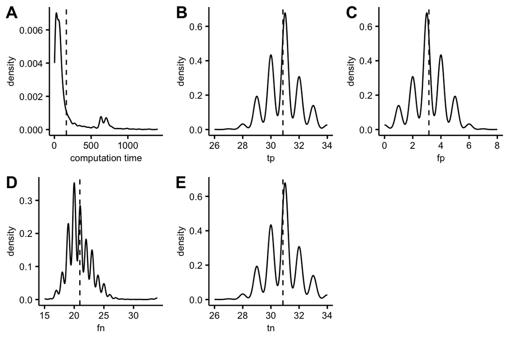

```r
metrics_annotation_df <- read_tsv(paste0(step_dir, 'metrics_table_auprc.tsv'))
parameters <- c('computation_time','tp', 'fp', 'fn', 'tn')

plot_par_all <- list()

for(i_plot in 1:(length(parameters))){

    parameter <- parameters[i_plot]

    p <- ggdensity(data = metrics_annotation_df,
                   x = parameter,
                   y = 'density',
                   add = 'mean',
                   xlab = str_replace_all(parameter, '_', ' ')) +
      theme(text = element_text(size = 8),
            legend.position = 'none')

    plot_par_all[[i_plot]] <- p
}

plot_grid(plotlist = plot_par_all, ncol = 3, labels = LETTERS[1:length(plot_par_all)]) -> grid2

grid2
```

### Analysis of networks characteristics dividing for specific parameters

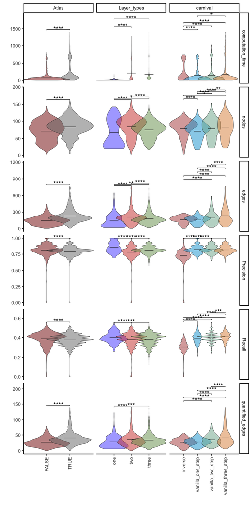

```r
metrics_annotation_df <- read_tsv('../results/4.network_generation/metrics_table_auprc.tsv')

parameters <- c('computation_time','nodes',
                'edges', 'quantified_edges',
                'Precision', 'Recall')

variable_types <- c('Atlas', 'Layer_types', 'carnival')

pivot_longer(data = metrics_annotation_df, cols = c('computation_time','nodes', 'edges', 'quantified_edges',
                                                    'Precision', 'Recall')) -> long_format

pivot_longer(long_format %>% mutate_at('Atlas', as.character),
             cols = c('Atlas', 'Layer_types', 'carnival'), names_to = 'variable_types', values_to = 'values2') -> long_format2


long_format2$variable_types <- factor(long_format2$variable_types , levels = c('Atlas', 'Layer_types', 'carnival'))

long_format2$name <- factor(long_format2$name , levels = c('computation_time', 'nodes', 'edges',   'Precision', 'Recall',
                                                                   'quantified_edges'))

#long_format2$name <- factor(long_format2$name , levels = c( 'Precision', 'Recall'))


long_format2$values2 <- factor(long_format2$values2, levels = c('FALSE', 'TRUE',
                                                                'one', 'two', 'three',
                                                                'inverse', 'vanilla_one_step',
                                                                'vanilla_two_step', 'vanilla_three_step'))


library(rstatix)

stat_test <- long_format2 %>%
  group_by(name, variable_types) %>%
  t_test(value ~ values2, p.adjust.method = "bonferroni") %>%
  mutate(y.position = max(long_format2$value) + 1) %>%
  add_xy_position(x = 'values2', scales = "free", fun = "max")


colors_violin<- list('FALSE' = '#800000',
     'TRUE' = '#767676',
     'one' = '#5050FF',
     'two' = '#CE3D32',
     'three' = '#749B58',

     'inverse' = "#B24745FF",
     'vanilla_one_step' = "#00A1D5FF",
     'vanilla_two_step' = "#79AF97FF",
     'vanilla_three_step' = "#DF8F44FF" )



long_format2 %>%
  ggplot(aes(y=value, x=values2)) +
  geom_violin(aes(fill = values2), width=2, size=0.2, alpha = .5) +
  facet_grid( name ~ variable_types, scales = 'free') +
  scale_fill_manual(values = colors_violin, labels = names(colors_violin)) +
  stat_summary(fun = mean, geom = "crossbar", width = 0.5, size = 0.1, color = "grey3") +
  #geom_point(color = 'grey3', alpha = .3, size = .3) +
  theme_classic() +
  theme(text = element_text(size=10),
        axis.text.x = element_text(angle = 90, hjust = 1, size = 8, vjust = .5),
        legend.position= 'none',
        legend.title = element_blank()) +
  xlab("") +
  ylab('') -> violin_performance

stat_test %>% relocate(variable_types, xmin, xmax) -> stat_test

stat_test$xmin[stat_test$variable_types == 'Layer_types'] <- stat_test$xmin[stat_test$variable_types == 'Layer_types'] - 2
stat_test$xmax[stat_test$variable_types == 'Layer_types'] <- stat_test$xmax[stat_test$variable_types == 'Layer_types'] - 2

stat_test$xmin[stat_test$variable_types == 'carnival'] <- stat_test$xmin[stat_test$variable_types == 'carnival'] - 5
stat_test$xmax[stat_test$variable_types == 'carnival'] <- stat_test$xmax[stat_test$variable_types == 'carnival'] - 5


violin_performance +
  stat_pvalue_manual(stat_test, label = "p.adj.signif",tip.length = .01, hide.ns = TRUE) -> violin_plot_significance

violin_plot_significance
```

**Figure 4 and S7. SignalingProfiler 2.0 network generation (Step2) parameters tuning** Impact of Ser/Thr Kinome Atlas integration, number of layers in the naïve network, and CARNIVAL flavors and types on computation time, the number of nodes, edges, Precision, Recall and on the interactions number validated by phosphoproteomics data, across 2989 generated models. The black line indicates the average y value. Statistical significance was computed with T-test statistical analysis (p-value < 0.05 *, < 0.01 **, < 0.001*** , < 0.0001 ****).

## Find the best model of family network

To find the best novel we developed a **combined score** that weights Precision, Recall, the diameter and clustering coefficient, the number of edges validated with phosphoproteomics, the computation time and the fit to the power law. The computation time, the diameter and the number of significant phosphorylation events were normalized to be in the same scale as precision and recall.

```r
metrics_annotation_df <- read_tsv(paste0(step_dir, 'metrics_table_auprc.tsv'))

# Normalize diameter and computation time
max_time <- max(metrics_annotation_df$computation_time)
metrics_annotation_df$normalized_time <- metrics_annotation_df$computation_time / max_time

max_diam <- max(metrics_annotation_df$diameter)
metrics_annotation_df$norm_diam <- metrics_annotation_df$diameter / max_diam

# Compute the proportion of significant edges over total edges
metrics_annotation_df %>% mutate(sign_ratio = significant_edges/edges) -> metrics_annotation_df

# Create a combined score
metrics_annotation_df <- metrics_annotation_df %>%
  mutate(combined_score_step2 = Precision*0.5 + Recall*0.5 + sign_ratio * 0.5 + norm_diam*0.5 + clust_coeff * 0.5 - (normalized_time * 0.2 + power_law_fit))

# Sort the data by the combined score
sorted_data <- metrics_annotation_df %>%
  arrange(desc(combined_score_step2)) %>%
  relocate(network_id, combined_score_step2)

head(sorted_data)
```

```
## # A tibble: 6 × 43
##   network_id  combined_score_step2 Atlas Direct PKN_filtering Connect_all
##   <chr>                      <dbl> <lgl> <lgl>  <lgl>         <lgl>
## 1 Network1554                 1.16 FALSE TRUE   TRUE          TRUE
## 2 Network4034                 1.15 FALSE TRUE   TRUE          TRUE
## 3 Network1398                 1.14 FALSE TRUE   FALSE         TRUE
## 4 Network3878                 1.13 FALSE TRUE   FALSE         TRUE
## 5 Network3958                 1.13 FALSE TRUE   FALSE         TRUE
## 6 Network920                  1.11 FALSE FALSE  FALSE         TRUE
## # ℹ 37 more variables: Layer_types <chr>, Carnival_types <chr>,
## #   Steps_numbers <chr>, TopDown <lgl>, Max_length1 <dbl>,
## #   `Max_length1-2` <chr>, `Max_length1-3` <chr>, Keep_only_connected <lgl>,
## #   PKN_time <dbl>, CARNIVAL_time <dbl>, nodes <dbl>, edges <dbl>,
## #   n_components <dbl>, clust_coeff <dbl>, diameter <dbl>, power_law_fit <dbl>,
## #   longest_path_AMPK <dbl>, longest_path_MTOR <dbl>,
## #   longest_path_Perturbation <dbl>, quantified_edges <dbl>, …
```

```r
#write_tsv(sorted_data, '../results/4.network_generation/sorted_data_network_family.tsv')
```

The **best model** is *Network1554*.